# Intro

In this project, the data are first imported from Kaggle. The text of each article is considered for feature engineering. Stemming and lemmatizing are both considered as possible candidates for data preparation; lemmatizing is chosen and applied through each article body. Tfidf is used for document vectorization. 5 models are built: a vanilla keras neural net, a logistic regression model, a single decision tree classifier, a random forest classifier, and a k-nearest neighbors classifier. Each model is scored for accuracy, precision, and recall. Each model is given a confusion matrix. Then, an averaging ensembling technique is applied across each model.

# Imports

```python
# keras neural network imports
from keras.models import Sequential, load_model
from keras.preprocessing import sequence
from keras.layers.core import Dense, Dropout, Activation, Flatten
from keras.layers import Embedding
from keras.layers import GlobalAveragePooling1D
from keras.optimizers import Adadelta,Adam,RMSprop
from keras.utils import np_utils
from keras.regularizers import l2

# logistic regression
from sklearn.linear_model import LogisticRegression

# decision tree model
from sklearn.tree import DecisionTreeClassifier

# random forest
from sklearn.ensemble import RandomForestClassifier

# k nearest neighbors
from sklearn.neighbors import KNeighborsClassifier

# normal imports
import pandas as pd
import numpy as np
import matplotlib.pyplot as plt
import itertools

# kaggle download and file manipulation
import os
import zipfile

# for string manipulation
import nltk
from nltk.corpus import stopwords
import string
from nltk.tokenize import word_tokenize
from nltk.stem import WordNetLemmatizer
from nltk.stem import SnowballStemmer
from sklearn.feature_extraction.text import TfidfVectorizer
from sklearn.model_selection import train_test_split

# metrics for model measurements
from sklearn import metrics
```

Importing the data from Kaggle. Obviously my api key has been redacted.

```python
os.environ['KAGGLE_USERNAME'] = 'pkseeg'
os.environ['KAGGLE_KEY'] = '-----'
! kaggle datasets download -d clmentbisaillon/fake-and-real-news-dataset
with zipfile.ZipFile("fake-and-real-news-dataset.zip","r") as zip_ref:
    zip_ref.extractall("fake-and-real-news-dataset/")

#! ls fake-and-real-news-dataset
fake = pd.read_csv('fake-and-real-news-dataset/Fake.csv')
true = pd.read_csv('fake-and-real-news-dataset/True.csv')

fake['target'] = 1
true['target'] = 0
data = pd.concat([fake,true], ignore_index=True)
```

```
fake-and-real-news-dataset.zip: Skipping, found more recently modified local copy (use --force to force download)
```

```python
print('We have '+str(len(data['text']))+' news articles in the dataset.')
print(str(round(len(data[data['target']==1])/len(data['target'])*100,2))+"% of articles in dataset are fake.")
```

```
We have 44898 news articles in the dataset.
52.3% of articles in dataset are fake.
```

# Text Preprocessing

## Lemmatization

Would lemmatization be better than stemming? Let's look at both.

```python
stemmer = SnowballStemmer("english")
lemmatizer = WordNetLemmatizer()
```

Here we'll build two functions for the text preprocessing - one using a lemmatizer, one using a stemmer. Both functions also remove punctuation and stopwords.

```python
def cleanStem(message):

    message = message.translate(str.maketrans('', '', string.punctuation))
    words = [stemmer.stem(word.lower()) for word in message.split() if word.lower() not in stopwords.words("english")]

    return " ".join(words)
def cleanLemma(message):

    message = message.translate(str.maketrans('', '', string.punctuation))
    words = [lemmatizer.lemmatize(word.lower()) for word in message.split() if word.lower() not in stopwords.words("english")]

    return " ".join(words)
```

Here we'll see what the differences were for the beginning of a typical news article.

```python
print("Original: "+data['text'][2][:100])
print("Stemmed: "+cleanStem(data['text'][2][:100]))
print("Lemmatized: "+cleanLemma(data['text'][2][:100]))
```

```
Original: On Friday, it was revealed that former Milwaukee S
Stemmed: friday reveal former milwauke
Lemmatized: friday revealed former milwaukee
```

We'll go with a lemmatizer because I personally believe they allow greater comparison across messages, giving greater depth to the data. Here we apply this cleaning lemmatization function across each article body in the dataset.

```python
data['text'] = data['text'].apply(cleanLemma)
```

Since lemmatization is very slow (this took my chromebook an hour or so), we will save the lemmatized text for easier access when re-running the kernel.

```python
#data.to_csv('lemmatized.csv')
data = pd.read_csv('lemmatized.csv')
```

Here's an example of the cleaned text.

```python
data['text'][0][:100]
```

[output not shown]

## Document vectorization

Next we'll convert our text into vectors using tfidf. Tfidf stands for 'term frequency-inverse document frequency.' Basically, tfidf goes beyond simply giving a count for how many times each word appears in a given document (see: countvectorizer) by giving more weight to those words which appear less frequently across all documents. This way, a high amount of unique words in one article body - for example, curse words in a fake news article that would rarely appear in a real news article - will be far easier to detect.

```python
vec = TfidfVectorizer(encoding = 'latin-1', strip_accents = 'unicode', stop_words = 'english',
                     max_df=1.0, min_df=0.025)
features = vec.fit_transform(data['text'].values.astype('U')).toarray()
print(features.shape)
```

```
(44898, 1179)
```

Here we split the data into training and testing data, with a 70/30 train/test split. Our target variable is 1 if the article is fake, 0 if it isn't.

```python
xtrain, xtest, ytrain, ytest = train_test_split(features, data['target'], stratify = data['target'], test_size = 0.30)
```

# Models

## Keras Neural Net

Here we build a simple keras neural network which has two hidden layers: a global average pooling layer, then a dense layer for prediction.

```python
max_features = 20000
batch_size = 50
embedding_dims = 512
epochs = 5

xtrain = sequence.pad_sequences(xtrain)
xtest = sequence.pad_sequences(xtest)

model = Sequential()
model.add(Embedding(max_features,
                    embedding_dims,
                    input_length=xtrain.shape[1]))

# we add a GlobalAveragePooling1D, which will average the embeddings
# of all words in the document
model.add(GlobalAveragePooling1D())

# We project onto a single unit output layer, and squash it with a sigmoid:
model.add(Dense(1, activation='sigmoid'))

model.compile(loss='binary_crossentropy',
              optimizer='adam',
              metrics=['accuracy'])

model.fit(xtrain, ytrain,
          batch_size=batch_size,
          epochs=epochs,
          validation_data=(xtest, ytest))
```

We then save the model for easier reboot access.

```python
# Save the model
#model.save('vanilla_net.h5')

# Recreate the exact same model purely from the file
model = load_model('vanilla_net.h5')
```

```python
batch_size = 50
score = model.evaluate(xtest, ytest,
                       batch_size=batch_size, verbose=1)
```

We can then use the test features (xtest) to predict the classes of each article body.

```python
# Predict the values from the validation dataset
ypred = model.predict(xtest)
# Convert predictions classes to one hot vectors
ypred_classes = np.argmax(ypred,axis = 1)
```

Here we calculate the accuracy, precision, and recall scores for the keras model.

```python
print('Accuracy: '+str(round(metrics.accuracy_score(ytest,ypred_classes),4)))
print('Precision: '+str(round(metrics.precision_score(ytest,ypred_classes),4)))
print('Recall: '+str(round(metrics.recall_score(ytest,ypred_classes),4)))
```

```
Accuracy: 0.477
Precision: 0.0
Recall: 0.0
```

```python
print("There were this many predicted fake articles: "+str(len(ypred_classes[ypred_classes==1])))
print("There were this many actual fake articles: "+str(len(ytest[ytest==1])))
```

```
There were this many predicted fake articles: 0
There were this many actual fake articles: 7045
```

This is really interesting. Our keras model never learned. It simply predicted that all articles weren't fake. I honestly don't understand why - I'm sure it's something simple that I misunderstand about neural networks. I'll be taking a deep learning class in the fall, so hopefully I'll learn some more things.

Here we can create a function for plotting the confusion matrix; we'll use this for each model we build.

```python
def plot_confusion_matrix(cm, classes,
                          normalize=False,
                          title='Confusion matrix',
                          cmap=plt.cm.Blues):
    """
    This function prints and plots the confusion matrix.
    Normalization can be applied by setting `normalize=True`.
    """
    plt.imshow(cm, interpolation='nearest', cmap=cmap)
    plt.title(title)
    plt.colorbar()
    tick_marks = np.arange(len(classes))
    plt.xticks(tick_marks, classes, rotation=45)
    plt.yticks(tick_marks, classes)

    if normalize:
        cm = cm.astype('float') / cm.sum(axis=1)[:, np.newaxis]

    thresh = cm.max() / 2.
    for i, j in itertools.product(range(cm.shape[0]), range(cm.shape[1])):
        plt.text(j, i, cm[i, j],
                 horizontalalignment="center",
                 color="white" if cm[i, j] > thresh else "black")

    plt.tight_layout()
    plt.ylabel('True label')
    plt.xlabel('Predicted label')
```

Here we see the confusing confusion matrix for the vanilla neural network.

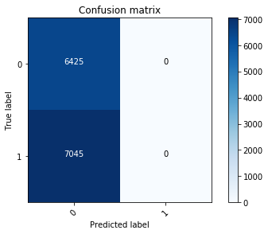

```python
confusion_mtx = metrics.confusion_matrix(ytest, ypred_classes)
plot_confusion_matrix(confusion_mtx, classes = range(2))
```

# Logistic Regression

We achieve pretty good results with the logistic regression model - 98% in accuracy, precision, and recall. Though our neural net didn't work out, we can see that the tfidf feature vectors do a good job separating the data.

```python
# Create logistic regression object
regressor = LogisticRegression()

# Train the model using the training sets
regressor.fit(xtrain, ytrain)

# Make predictions using the testing set
regressor_ypred = regressor.predict(xtest)
```

```python
print('Accuracy: '+str(round(metrics.accuracy_score(ytest,regressor_ypred),4)))
print('Precision: '+str(round(metrics.precision_score(ytest,regressor_ypred),4)))
print('Recall: '+str(round(metrics.recall_score(ytest,regressor_ypred),4)))
```

```
Accuracy: 0.9832
Precision: 0.9863
Recall: 0.9815
```

```python
confusion_mtx = metrics.confusion_matrix(ytest, regressor_ypred)
```

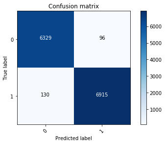

```python
plot_confusion_matrix(confusion_mtx, classes=range(2))
```

# Decision Tree Classifier

Our decision tree classifier is even better than the logistic regression model - 99% accuracy in all 3 measurements. Let's see what a random forest model could do.

```python
# Create decision tree object
tree = DecisionTreeClassifier()

# Train the model using the training sets
tree.fit(xtrain, ytrain)

# Make predictions using the testing set
tree_ypred = tree.predict(xtest)
```

```python
print('Accuracy: '+str(round(metrics.accuracy_score(ytest,tree_ypred),4)))
print('Precision: '+str(round(metrics.precision_score(ytest,tree_ypred),4)))
print('Recall: '+str(round(metrics.recall_score(ytest,tree_ypred),4)))
```

```
Accuracy: 0.9948
Precision: 0.9943
Recall: 0.9957
```

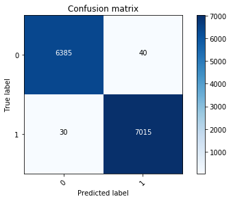

```python
confusion_mtx = metrics.confusion_matrix(ytest, tree_ypred)
plot_confusion_matrix(confusion_mtx, classes=range(2))
```

# Random Forest

Our random forest model was basically the same as the decision tree model.

```python
# Create random forest classifier object
rfc = RandomForestClassifier(class_weight="balanced")

# Train the model using the training sets
rfc.fit(xtrain, ytrain)

# Make predictions using the testing set
rfc_ypred = rfc.predict(xtest)
```

```python
print('Accuracy: '+str(round(metrics.accuracy_score(ytest,rfc_ypred),4)))
print('Precision: '+str(round(metrics.precision_score(ytest,rfc_ypred),4)))
print('Recall: '+str(round(metrics.recall_score(ytest,rfc_ypred),4)))
```

```
Accuracy: 0.9912
Precision: 0.9941
Recall: 0.9889
```

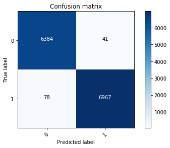

```python
confusion_mtx = metrics.confusion_matrix(ytest, rfc_ypred)
plot_confusion_matrix(confusion_mtx, classes=range(2))
```

# K Nearest Neighbors

K nearest neighbors takes FOREVER to fit and use in prediction, but it is another way of looking at the data. Since we had so many observations, I opted to use only the 3 closest neighbors.

```python
knn = KNeighborsClassifier(n_neighbors=3)
```

```python
# Train the model using the training sets
knn.fit(xtrain, ytrain)
```

```
KNeighborsClassifier(algorithm='auto', leaf_size=30, metric='minkowski',
                     metric_params=None, n_jobs=None, n_neighbors=3, p=2,
                     weights='uniform')
```

```python
# Make predictions using the testing set
knn_ypred = knn.predict(xtest)
```

```python
print('Accuracy: '+str(round(metrics.accuracy_score(ytest,knn_ypred),4)))
print('Precision: '+str(round(metrics.precision_score(ytest,knn_ypred),4)))
print('Recall: '+str(round(metrics.recall_score(ytest,knn_ypred),4)))
```

```
Accuracy: 0.7662
Precision: 0.7083
Recall: 0.9402
```

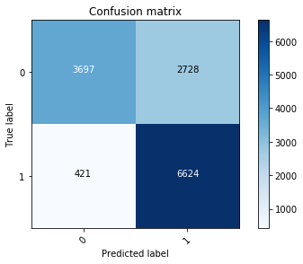

```python
confusion_mtx = metrics.confusion_matrix(ytest, knn_ypred)
plot_confusion_matrix(confusion_mtx, classes=range(2))
```

# Ensembling via Averaging Method

```python
pred1=model.predict_proba(xtest)
pred2=regressor.predict_proba(xtest)
pred3=tree.predict_proba(xtest)
pred4=rfc.predict_proba(xtest)
pred5=knn.predict_proba(xtest)
```

```python
# remove neural net prediction (worthless until I fix it)
finalpred=(pred2+pred3+pred4+pred5)/4
```

```python
final_classes = []
for i in range(len(finalpred)):
    if finalpred[i][1] > 0.5:
        final_classes.append(1)
    else:
        final_classes.append(0)
```

```python
print('Accuracy: '+str(round(metrics.accuracy_score(ytest,final_classes),4)))
print('Precision: '+str(round(metrics.precision_score(ytest,final_classes),4)))
print('Recall: '+str(round(metrics.recall_score(ytest,final_classes),4)))
```

```
Accuracy: 0.995
Precision: 0.9936
Recall: 0.9967
```

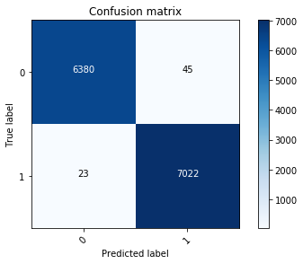

```python
confusion_mtx = metrics.confusion_matrix(ytest, final_classes)
plot_confusion_matrix(confusion_mtx, classes=range(2))
```

Future efforts could use some more advanced ensembling techniques like stacking or blending to build an even more robust model - but this was pretty good! Lemmatizing and tfidf work well together for rich text data, even after you remove any less-frequent words.